# Buoy Sea Surface Temperature Data

Andrew Edwards

Last rendered on 20 September, 2024

## Daily average sea surface temperature from buoys

```r
library(pacea)
library(dplyr)
library(tibble)  # Else prints all of a tibble
library(ggplot2)
```

Metadata for the buoys is given by

```r
buoy_metadata
```

```
#> # A tibble: 19 × 9
#>    wmo_id name    type  latitude longitude water_depth_m col_key stn_id name_key
#>    <fct>  <fct>   <fct>    <dbl>     <dbl>         <dbl> <fct>   <fct>  <fct>
#>  1 46004  Middle… NOMAD     51.0     -136.          3600 #0000FF C46004 C46004 …
#>  2 46036  South … NOMAD     48.4     -134.          3500 #FF0000 C46036 C46036 …
#>  3 46131  Sentry… 3 me…     49.9     -125.            18 #00FF00 C46131 C46131 …
#>  4 46132  South … 3 me…     49.7     -128.          2040 #000033 C46132 C46132 …
#>  5 46134  ECOBUO… 3 me…     48.7     -123.            65 #000033 C46134 C46134 …
#>  6 46145  Centra… 3 me…     54.4     -132.           257 #FF00B6 C46145 C46145 …
#>  7 46146  Halibu… 3 me…     49.3     -124.            43 #005300 C46146 C46146 …
#>  8 46147  South … 3 me…     51.8     -131.          2000 #FFD300 C46147 C46147 …
#>  9 46181  Nanakw… 3 me…     53.8     -129.            22 #009FFF C46181 C46181 …
#> 10 46183  North … 3 me…     53.6     -131.            60 #9A4D42 C46183 C46183 …
#> 11 46184  North … NOMAD     53.9     -139.          3200 #00FFBE C46184 C46184 …
#> 12 46185  South … 3 me…     52.4     -130.           228 #783FC1 C46185 C46185 …
#> 13 46204  West S… 3 me…     51.4     -129.           222 #1F9698 C46204 C46204 …
#> 14 46205  West D… 3 me…     54.2     -134.          2675 #FFACFD C46205 C46205 …
#> 15 46206  La Per… 3 me…     48.8     -126.            73 #FE8F42 C46206 C46206 …
#> 16 46207  East D… 3 me…     50.9     -130.          2215 #DD00FF C46207 C46207 …
#> 17 46208  West M… 3 me…     52.5     -133.          2950 #02AD24 C46208 C46208 …
#> 18 46303  S. Geo… <NA>      49.0     -123.            NA #C8FF00 C46303 C46303 …
#> 19 46304  Entran… <NA>      49.3     -123.            NA #886C00 C46304 C46304 …
```

which includes each buoy’s World Meteorological Organisation’s weather station id (`wmo_id`), its ‘common name’ (`name`), location, and depth of the water in which the buoy resides. See `?buoy_metadata` for descriptions of all columns. The full names of all buoys are

```r
buoy_metadata$name
```

```
#>  [1] Middle NOMAD           South NOMAD            Sentry Shoal
#>  [4] South Brooks           ECOBUOY_1              Central Dixon Entrance
#>  [7] Halibut Bank           South Moresby          Nanakwa Shoal
#> [10] North Hecate Strait    North NOMAD            South Hecate Strait
#> [13] West Sea Otter         West Dixon Entrance    La Perouse Bank
#> [16] East Dellwood Knolls   West Moresby           S. Georgia Strait
#> [19] Entrance English Bay
#> 19 Levels: Central Dixon Entrance East Dellwood Knolls ... West Sea Otter
```

The locations of the buoys are given by

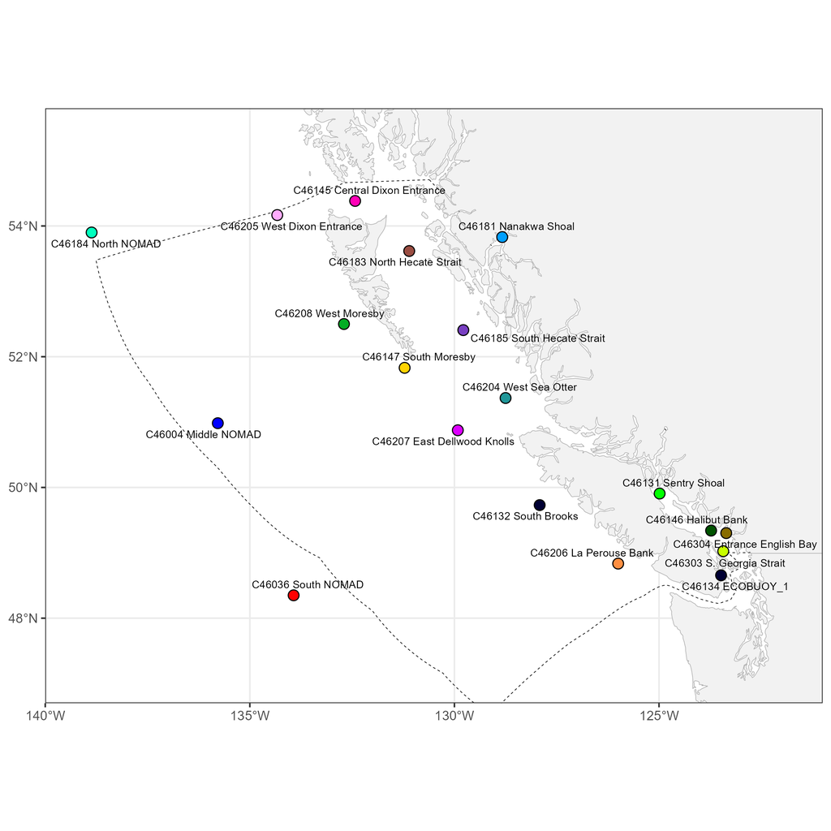

(built with code in data-raw/buoys/buoys-map.R), and also shown at https://github.com/IOS-OSD-DPG/Pacific_SST_Monitoring#eccc-buoy-data.

Some of the recent data are also plotted on that website, by Andrea Hilborn, Charles Hannah and Lu Guan, which is automatically updated roughly every week (so look there for a quick glance at recent conditions). For `pacea` we have, with Andrea, adapted some of that code to include the data and create plotting functions in our package.

The wrangling of data is taken care of within `pacea`, and includes using protocols to remove certain flagged data, dealing with timezones and pesky daylight savings time changes, and averaging over a day (the original raw data are even higher resolution). We are still refining this to remove outliers – this has to be somewhat manual.

The sst value are saved in a tibble, which also has class `pacea_buoy`

```r
buoy_sst
```

```
#> # A tibble: 206,901 × 3
#>    date       stn_id   sst
#>    <date>     <fct>  <dbl>
#>  1 1988-08-05 C46004  12.8
#>  2 1988-08-06 C46004  12.7
#>  3 1988-08-07 C46004  12.5
#>  4 1988-08-08 C46004  12.5
#>  5 1988-08-09 C46004  12.6
#>  6 1988-08-10 C46004  12.6
#>  7 1988-08-11 C46004  12.7
#>  8 1988-08-12 C46004  12.7
#>  9 1988-08-13 C46004  12.8
#> 10 1988-08-14 C46004  12.9
#> # ℹ 206,891 more rows
```

```r
tail(buoy_sst)
```

```
#> # A tibble: 6 × 3
#>   date       stn_id   sst
#>   <date>     <fct>  <dbl>
#> 1 2024-09-14 C46304  17.0
#> 2 2024-09-15 C46304  16.8
#> 3 2024-09-16 C46304  16.2
#> 4 2024-09-17 C46304  15.0
#> 5 2024-09-18 C46304  15.4
#> 6 2024-09-19 C46304  15.3
```

with `stn_id` specifying each buoy as described above in `buoy_metadata`, and `date` based on UTC -8 hours (i.e. Pacific Standard Time, not changing due to daylight savings), and `sst` is the mean SST (deg C) for that day at that station; see `?buoy_sst` for full details.

To see the ranges of dates for each buoy, use `dplyr` functions in the usual way:

```r
buoy_ranges <- buoy_sst %>%
  group_by(stn_id) %>%
  summarise(start = min(date),
            end = max(date))
buoy_ranges
```

```
#> # A tibble: 19 × 3
#>    stn_id start      end
#>    <fct>  <date>     <date>
#>  1 C46004 1988-08-05 2023-06-17
#>  2 C46036 1987-09-23 2024-07-09
#>  3 C46131 1992-10-20 2024-09-19
#>  4 C46132 1994-09-07 2024-09-19
#>  5 C46134 2001-02-20 2016-12-08
#>  6 C46145 1991-04-17 2024-09-19
#>  7 C46146 1992-03-14 2024-09-19
#>  8 C46147 1993-06-17 2024-09-19
#>  9 C46181 1988-12-07 2024-09-19
#> 10 C46183 1991-05-15 2023-12-11
#> 11 C46184 1987-09-21 2024-05-28
#> 12 C46185 1991-09-13 2024-09-19
#> 13 C46204 1989-09-08 2024-01-21
#> 14 C46205 1988-11-23 2024-09-19
#> 15 C46206 1988-11-23 2024-09-19
#> 16 C46207 1989-10-18 2022-09-07
#> 17 C46208 1990-07-12 2023-08-03
#> 18 C46303 2019-10-01 2024-07-26
#> 19 C46304 2019-10-02 2024-09-19
```

Plot data from a single buoy for all years, the default is for buoy C46205:

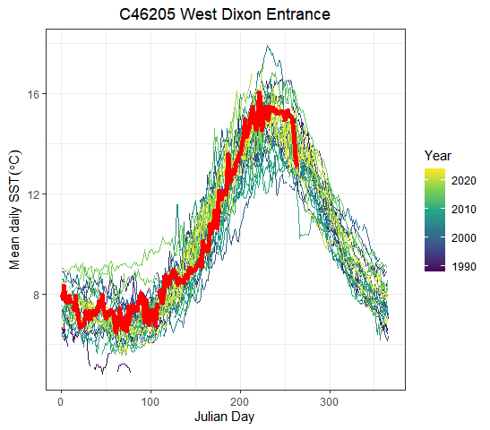

```r
plot(buoy_sst)
```

To see data from each buoy in turn:

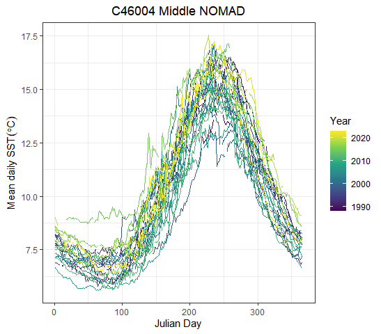

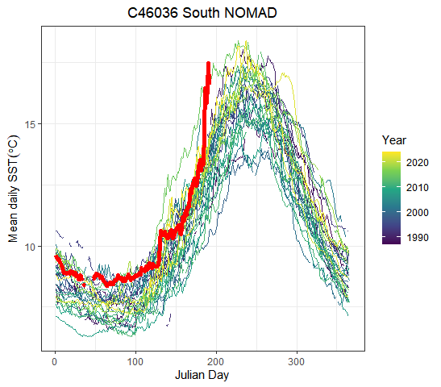

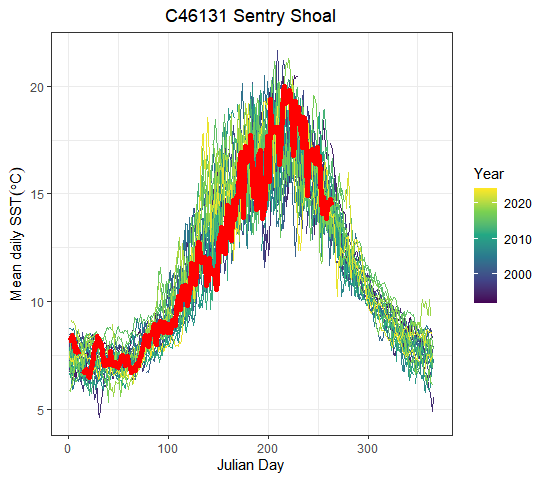

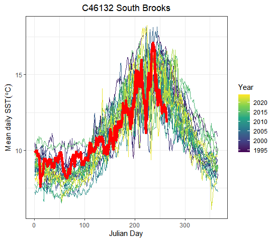

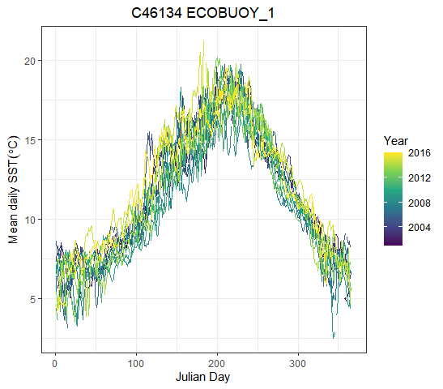

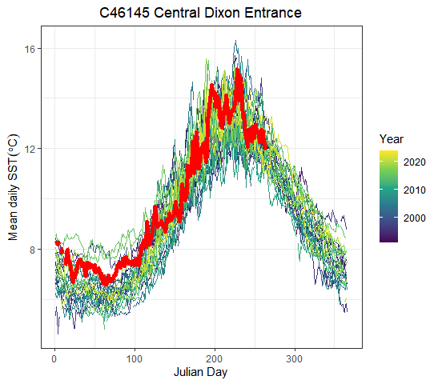

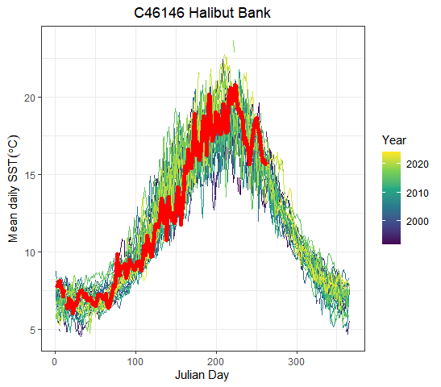

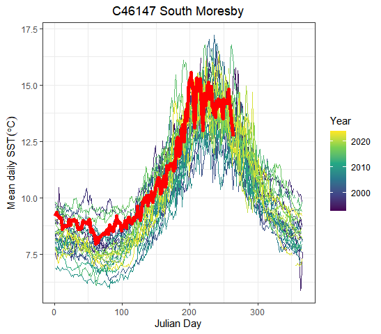

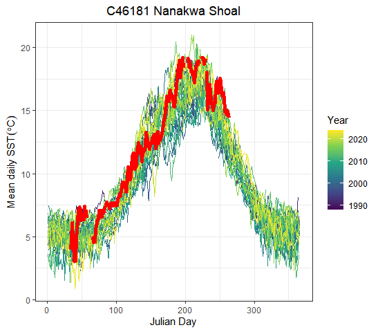

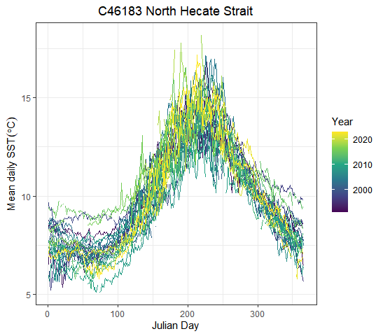

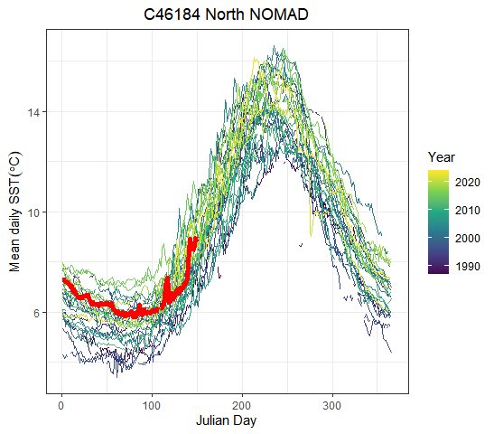

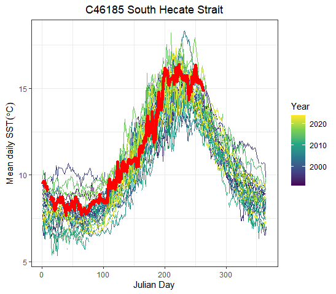

[7 more figures not shown]

```r
for(i in 1:nrow(buoy_metadata)){
  plot(buoy_sst,
       stn_id = buoy_metadata[i, ]$stn_id) %>% print()
}
```

We might adapt Andrea Hilborn’s code (saved below in the .Rmd) to produce a panel plot of all buoys at once, to give a figure resembling that at https://github.com/IOS-OSD-DPG/Pacific_SST_Monitoring/blob/main/figures/current/Daily_mean_buoy_overview_2023.png. But for pacea users the individual buoys are probably sufficient.